# Breast Cancer Classification

The American Cancer Society estimates that about there will be about 276,480 new cases of breast cancer this year and around 42,170 will die from breast cancer in 2020. [source](https://www.cancer.org/cancer/breast-cancer/about/how-common-is-breast-cancer.html)

Abnormal growths in the breasts are often classified as either benign or malignant. Most lumps can be classified as benign, and they’re very common and not life threatening. On the other hand, malignant tumors can result in metastatic tumors—spreading beyond the site of origin. These are cancerous tumors that can be life threatening once it metastasizes throughout the body. Therefore, it is important to be able to classify whether a lump is benign or malignant. Patients usually go through several tests before an official diagnosis is made.

[figure not shown]

There is a type of test using what’s called a fine needle aspirate (FNA) that be used to take an image of a cell nucleus from the growth. The properties of the cell nucleus taken from the image can be used to classified whether the cell is benign or malignant. This will be a tutorial will attempt to come up with a model that can classify these growths.

# Setting up the data

This data will be from Breast Cancer Wisconsin (Diagnostic) Data Set on [Kaggle](https://www.kaggle.com/uciml/breast-cancer-wisconsin-data). The source of the information about the cell features can be found on the dataset's [Kaggle](https://www.kaggle.com/uciml/breast-cancer-wisconsin-data) page.

First, we will need to load these libraries.

```python
import pandas as pd
import numpy as np
import seaborn as sns
import matplotlib.pyplot as plt

import sklearn.ensemble
import sklearn.model_selection
from sklearn.linear_model import LogisticRegressionCV
from sklearn.model_selection import GridSearchCV
from sklearn.neighbors import KNeighborsClassifier
from sklearn.ensemble import RandomForestClassifier
```

Kaggle provided a nice csv file, so we can easily read the data into a pandas dataframe

```python
df = pd.read_csv('data.csv')
df.head()
```

|  | id | diagnosis | radius_mean | texture_mean | perimeter_mean | area_mean | smoothness_mean | compactness_mean | concavity_mean | concave points_mean | ... | texture_worst | perimeter_worst | area_worst | smoothness_worst | compactness_worst | concavity_worst | concave points_worst | symmetry_worst | fractal_dimension_worst | Unnamed: 32 |
| --- | --- | --- | --- | --- | --- | --- | --- | --- | --- | --- | --- | --- | --- | --- | --- | --- | --- | --- | --- | --- | --- |
| 0 | 842302 | M | 17.99 | 10.38 | 122.80 | 1001.0 | 0.11840 | 0.27760 | 0.3001 | 0.14710 | ... | 17.33 | 184.60 | 2019.0 | 0.1622 | 0.6656 | 0.7119 | 0.2654 | 0.4601 | 0.11890 | NaN |
| 1 | 842517 | M | 20.57 | 17.77 | 132.90 | 1326.0 | 0.08474 | 0.07864 | 0.0869 | 0.07017 | ... | 23.41 | 158.80 | 1956.0 | 0.1238 | 0.1866 | 0.2416 | 0.1860 | 0.2750 | 0.08902 | NaN |
| 2 | 84300903 | M | 19.69 | 21.25 | 130.00 | 1203.0 | 0.10960 | 0.15990 | 0.1974 | 0.12790 | ... | 25.53 | 152.50 | 1709.0 | 0.1444 | 0.4245 | 0.4504 | 0.2430 | 0.3613 | 0.08758 | NaN |
| 3 | 84348301 | M | 11.42 | 20.38 | 77.58 | 386.1 | 0.14250 | 0.28390 | 0.2414 | 0.10520 | ... | 26.50 | 98.87 | 567.7 | 0.2098 | 0.8663 | 0.6869 | 0.2575 | 0.6638 | 0.17300 | NaN |
| 4 | 84358402 | M | 20.29 | 14.34 | 135.10 | 1297.0 | 0.10030 | 0.13280 | 0.1980 | 0.10430 | ... | 16.67 | 152.20 | 1575.0 | 0.1374 | 0.2050 | 0.4000 | 0.1625 | 0.2364 | 0.07678 | NaN |

5 rows × 33 columns

The author of the data also provided the "worst" or the largest of these features to the dataset. We will be removing these columns and focus instead of the mean values.  
This can be done doing the following:

```python
df = df.iloc[:,0:12]
df['diag_bin'] = df['diagnosis'].apply(lambda x: 1 if x == 'M' else 0)
df.head()
```

|  | id | diagnosis | radius_mean | texture_mean | perimeter_mean | area_mean | smoothness_mean | compactness_mean | concavity_mean | concave points_mean | symmetry_mean | fractal_dimension_mean | diag_bin |
| --- | --- | --- | --- | --- | --- | --- | --- | --- | --- | --- | --- | --- | --- |
| 0 | 842302 | M | 17.99 | 10.38 | 122.80 | 1001.0 | 0.11840 | 0.27760 | 0.3001 | 0.14710 | 0.2419 | 0.07871 | 1 |
| 1 | 842517 | M | 20.57 | 17.77 | 132.90 | 1326.0 | 0.08474 | 0.07864 | 0.0869 | 0.07017 | 0.1812 | 0.05667 | 1 |
| 2 | 84300903 | M | 19.69 | 21.25 | 130.00 | 1203.0 | 0.10960 | 0.15990 | 0.1974 | 0.12790 | 0.2069 | 0.05999 | 1 |
| 3 | 84348301 | M | 11.42 | 20.38 | 77.58 | 386.1 | 0.14250 | 0.28390 | 0.2414 | 0.10520 | 0.2597 | 0.09744 | 1 |
| 4 | 84358402 | M | 20.29 | 14.34 | 135.10 | 1297.0 | 0.10030 | 0.13280 | 0.1980 | 0.10430 | 0.1809 | 0.05883 | 1 |

We've also set new attribute called diag_bin to represent 1 if the diagnosis is 'M' and 0 if the diagnosis is 'B'. This will make things easier during the following phases.

In order to train and validate a model, we need to split the dataset into two datasets--a training set and a validation set. we will be doing a 50-50 split sampled randomly.

```python
df_train = df.sample(frac = 0.5)
df_validate = df.drop(df_train.index).reset_index(drop=True)
df_train = df_train.reset_index(drop=True)
```

The training set is sampled randomly from the entire dataframe and the validate set is assigned the leftovers using drop. After this, the sets' indexes need to be reset using reset_index.

# Data Analysis and Visualization

It's important to visualize the data before working with it. Below are boxplots comparing the distribution of each of the attributes for the diagnosis.

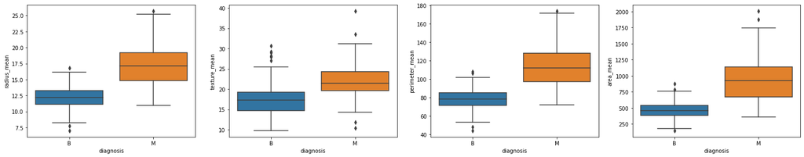

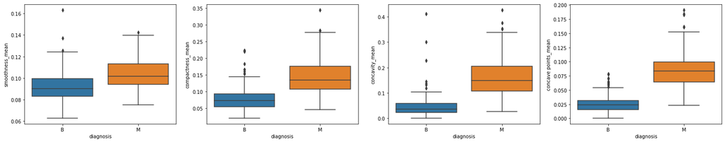

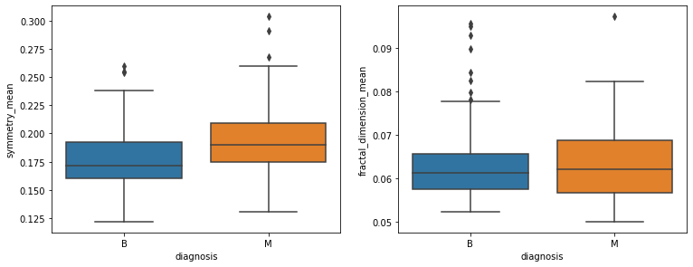

```python
fig, (ax1, ax2, ax3, ax4) = plt.subplots(1,4)
sns.boxplot(x = 'diagnosis', y = 'radius_mean', data = df_train, ax = ax1)
sns.boxplot(x = 'diagnosis', y = 'texture_mean', data = df_train, ax = ax2)
sns.boxplot(x = 'diagnosis', y = 'perimeter_mean', data = df_train, ax = ax3)
sns.boxplot(x = 'diagnosis', y = 'area_mean', data = df_train, ax = ax4)
plt.subplots_adjust(right = 3.5, bottom = 0.01)
plt.show()

fig, (ax1, ax2, ax3, ax4) = plt.subplots(1,4)
sns.boxplot(x = 'diagnosis', y = 'smoothness_mean', data = df_train, ax = ax1)
sns.boxplot(x = 'diagnosis', y = 'compactness_mean', data = df_train, ax = ax2)
sns.boxplot(x = 'diagnosis', y = 'concavity_mean', data = df_train, ax = ax3)
sns.boxplot(x = 'diagnosis', y = 'concave points_mean', data = df_train, ax = ax4)
plt.subplots_adjust(right = 3.5, bottom = 0.01)
plt.show()

fig, (ax1, ax2) = plt.subplots(1,2)
sns.boxplot(x = 'diagnosis', y = 'symmetry_mean', data = df_train, ax = ax1)
sns.boxplot(x = 'diagnosis', y = 'fractal_dimension_mean', data = df_train, ax = ax2)
plt.subplots_adjust(right = 1.75, bottom = 0.01)
plt.show()
```

The raw numbers of the plots are not as important as the visualization of the distribution and the differences between benign and malignant tumors. Just from looking over the graphs, we can see that there is definitely a pattern between the two types of tumors. Overall, malignant tumors seem to have higher values than the benign cases.

It's also important to look at the correlation between the variables to determine if there are any notable relationships.

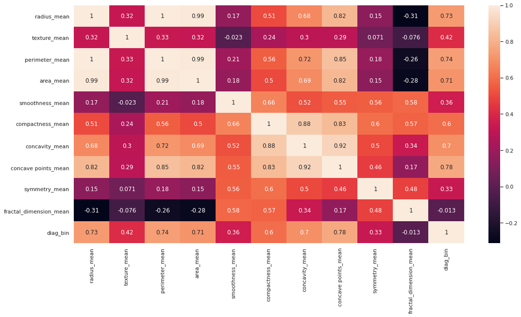

```python
corr = df.iloc[:,2:13].corr()
sns.heatmap(corr, annot=True)
sns.set(rc={'figure.figsize':(18,9)})
plt.show()
```

There are some correlation values that are expected such as the area_mean and the perimeter mean, but there are those like the concavity_mean and compactness_mean that are correlated in a not so obvious way. The most important part of the graph is the last row; the diagnosis vs the independent variables. Here we see which predictor has the highest correlation with the outcome. The most notable predictors are radius_mean, perimeter_mean, area_mean, concavity_mean, and concave points_mean. These all seems highly important in predicting the outcome.

# Model selection

There are several different models to choose from for this dataset. An obvious choice would be logistic regression since the output is a categorical variable with two outcomes. Before we begin, we need to separate the dependent and independent variables from the training and validation dataframes

```python
x_train = df_train[['radius_mean', 'texture_mean', 'perimeter_mean', 'area_mean', 'smoothness_mean', \
                    'compactness_mean', 'concavity_mean', 'concave points_mean', 'symmetry_mean', 'fractal_dimension_mean']]
y_train = df_train['diag_bin']

x_valid = df_validate[['radius_mean', 'texture_mean', 'perimeter_mean', 'area_mean', 'smoothness_mean', \
                    'compactness_mean', 'concavity_mean', 'concave points_mean', 'symmetry_mean', 'fractal_dimension_mean']]
y_valid = df_validate['diag_bin']
```

The idea behind model selection is taking the training data and coming up with a model that can predict future values. In this case, we use x_train and y_train from the training set to train the model. For each type of model, there are hyperparameters to increase the accuracy of the model. The problem is that it is often difficult to know what the hyperparameter should be set to. Therefore, we will introduce a technique called cross validation that test serveral models with different hyperparameters and choose the one that gives the model the lowest predicted error. Once the model is chosen, it is important to validate the model before sending out into the real world. In this project, we will input x_valid from the validation set into the model and check the output using y_valid.

## Logistic regression

```python
logistic_regression = LogisticRegressionCV(cv = 5, max_iter=1200000, penalty = 'l1', solver = 'liblinear').fit(x_train, y_train)
y_pred = logistic_regression.predict(x_valid)

confusion_matrix = pd.crosstab(y_valid, y_pred, rownames=['Actual'], colnames=['Predicted'])
confusion_matrix
```

| Predicted Actual | 0 | 1 |
| --- | --- | --- |
| 0 | 173 | 8 |
| 1 | 7 | 97 |

Here we trained a logistic regression model using 5 fold cross validation and the Lasso penalty. The choice of logistic regression over regular regression came from the fact the output we are trying to predict categorical variables with two outcomes. Regular regression is better at predicted numerical values.

Combining the predicted values with the actual values, we end up with a confusion matrix for the predicted values vs actual values. Using the confusion matrix, we can calculate the testing accuracy and the error rates of your model on the testing data.

```python
accuracy = (confusion_matrix[0][0] + confusion_matrix[1][1])/len(df_train)
false_positive = (confusion_matrix[1][0])/(confusion_matrix[1][0] + confusion_matrix[0][0])
false_negative = (confusion_matrix[0][1])/(confusion_matrix[1][1] + confusion_matrix[0][1])

print("accuracy:" + str(accuracy))
print("false_positive: " + str(false_positive))
print("false_negative:" + str(false_negative))
```

```
accuracy:0.9507042253521126
false_positive: 0.04419889502762431
false_negative:0.0673076923076923
```

## KNN

Here we use K nearest neighbors with 5 fold cross validation. I'm testing k = 1 to 50 and choosing the k that has the best predicted testing error.

```python
knearest = KNeighborsClassifier()
parameters_knearest = {'n_neighbors': np.arange(1, 50)}
knearest_cv = GridSearchCV(knearest, parameters_knearest, cv=5).fit(x_train, y_train)
y_pred = knearest_cv.predict(x_valid)

knearest_cv.best_params_
```

```
{'n_neighbors': 6}
```

The k that yields the best estimated tested error is k = 6

```python
confusion_matrix = pd.crosstab(y_valid, y_pred, rownames=['Actual'], colnames=['Predicted'])
confusion_matrix
```

| Predicted Actual | 0 | 1 |
| --- | --- | --- |
| 0 | 175 | 6 |
| 1 | 23 | 81 |

```python
accuracy = (confusion_matrix[0][0] + confusion_matrix[1][1])/len(df_train)
false_positive = (confusion_matrix[1][0])/(confusion_matrix[1][0] + confusion_matrix[0][0])
false_negative = (confusion_matrix[0][1])/(confusion_matrix[1][1] + confusion_matrix[0][1])

print("accuracy:" + str(accuracy))
print("false_positive: " + str(false_positive))
print("false_negative:" + str(false_negative))
```

```
accuracy:0.9014084507042254
false_positive: 0.03314917127071823
false_negative:0.22115384615384615
```

The knn model performed worse on the validation set compared the logistic regression model. There are way more false negatives which could be an issue in this type of setting.

## Random forest

Lastly, this is random forests with 5 fold cross validation using 500 trees. The hyperparameters are 2,4,6,8,10 randomly chosen predictors during the bagging process.

```python
rf = RandomForestClassifier(n_estimators=500)
parameters_rf = {'max_features': [2,4,6,8,10]}
rf_cv = GridSearchCV(rf, parameters_rf, cv=5).fit(x_train, y_train)
y_pred = rf_cv.predict(x_valid)

rf_cv.best_params_
```

```
{'max_features': 2}
```

Cross validation determined that the best hyperparameter was 2.

```python
confusion_matrix = pd.crosstab(y_valid, y_pred, rownames=['Actual'], colnames=['Predicted'])
confusion_matrix
```

| Predicted Actual | 0 | 1 |
| --- | --- | --- |
| 0 | 168 | 13 |
| 1 | 7 | 97 |

```python
accuracy = (confusion_matrix[0][0] + confusion_matrix[1][1])/len(df_train)
false_positive = (confusion_matrix[1][0])/(confusion_matrix[1][0] + confusion_matrix[0][0])
false_negative = (confusion_matrix[0][1])/(confusion_matrix[1][1] + confusion_matrix[0][1])

print("accuracy:" + str(accuracy))
print("false_positive: " + str(false_positive))
print("false_negative:" + str(false_negative))
```

```
accuracy:0.9330985915492958
false_positive: 0.0718232044198895
false_negative:0.0673076923076923
```

This performed similarly to logistic regression.

## Conclusion

Through model selection using cross validation, we managed to achieve around 90% accuracy in classifying whether a tumor is benign or malignant. At first glance, this doesn't seem very good considering this is an important medical diagnosis. However, I would say it's acceptable considering how the models only has 10 predictors. Also, we only has 569 observation and only half were used to train the model. If we had more data to work with, the models would probably be more accurate and would have less false positive and false negative cases.

From these three models, I would probably choose the logistic regression model because I could easily tune the threshold value for choosing benign or malignant. Right now, it's set to the default value of 0.5, but in the case that I want to reduce the number of false negatives, I could just adjust the value.